# transmitter_analyses

## Topic modeling of the fMRI literature

In this analysis we take results obtained by applying [BERTopic](https://maartengr.github.io/BERTopic/index.html) to text from PubMed abstracts that match the following query:

```
'("fMRI" OR "functional MRI" OR "functional magnetic resonance i
maging") AND (brain OR neural OR neuroscience OR neurological OR psychiatric OR
psychology) AND %d[DP]' % year
```

We focus here on the years 2002 through 2022; we excluded earlier years because the number of matching pubmed abstracts for those earlier years was quite small.

First we load the relevant functions:

```python
from fmritopics.fit_dynamic_topic_model import load_data, get_embeddings
from fmritopics.analyze_dynamic_topics import (
    load_model,
    get_topics_over_time,
    get_hierarchical_topics,
    get_clustered_topics,
    plot_hierarchical_topics,
    get_top_topics_over_time,
    plot_top_topics,
    get_slopes
)
from collections import defaultdict
import pandas as pd
import umap
import umap.plot
import numpy as np
import matplotlib.pyplot as plt
import os
import seaborn as sns
import matplotlib.pyplot as plt
from bertopic import BERTopic
from bertopic.representation import OpenAI
import openai

os.environ['PYTORCH_ENABLE_MPS_FALLBACK'] = '1'
```

Now we need to select the topic modeling parameters. There are two main parameters that determine the number of topics in BERTopic: The number of neighbors used in the UMAP dimensionality reduction step, and the minimum cluster size for the HDBSCAN clustering step. We ran models with various values of these parameters; while the overall conclusions are robust to these different parameters, specific differences in topics and their changes over time did occur for some values.

```python
# fit_dynamic_topic_model.py --device mps --min_cluster_size 500 --n_neighbors 25 --use_gpt4 --overwrite --reduce_topics

min_cluster_size = 500
n_neighbors = 40

datadir = 'data'
llm = 'gpt-4'
modeldir = '/Users/poldrack/Dropbox/code/fmri-topicmodeling/models'
```

```python
sentences, years = load_data(datadir)

minclust, nneighbors = min_cluster_size, n_neighbors

topic_model, embedding_model, model_name = load_model(
    minclust, nneighbors, modeldir, llm=llm)

topics_over_time = get_topics_over_time(sentences, years, topic_model)

hierarchical_topics, tree = get_hierarchical_topics(topic_model, sentences, viz=True)

print(f'Proportion of outliers: {np.mean(np.array(topic_model.topics_) == -1)}')
```

```
File data/bigrammed_cleaned_abstracts_1991.pkl does not exist
Loaded model from /Users/poldrack/Dropbox/code/fmri-topicmodeling/models/model-bertopic_minclust-500_nneighbors-40_gpt-4/model-bertopic_minclust-500_nneighbors-40_gpt-4
getting topics over time
```

```
32it [00:08,  3.62it/s]
```

```
Proportion of outliers: 0.26346931318584177
```

```python
topics_over_time
```

|  | Topic | Words | Frequency | Timestamp | Sum | Probability |
| --- | --- | --- | --- | --- | --- | --- |
| 180 | -1 | cortex, task, visual, neural, motor | 208 | 2002-01-01 | 901 | 0.230855 |
| 181 | 0 | time, spatial, noise, component, epi | 163 | 2002-01-01 | 901 | 0.180910 |
| 182 | 1 | language, auditory, word, left, processing | 125 | 2002-01-01 | 901 | 0.138735 |
| 183 | 2 | older, adult, disease, alzheimer, memory | 24 | 2002-01-01 | 901 | 0.026637 |
| 184 | 3 | schizophrenia, patient, schizophrenic, group, ... | 25 | 2002-01-01 | 901 | 0.027747 |
| ... | ... | ... | ... | ... | ... | ... |
| 783 | 23 | tbi, injury, mtbi, concussion, traumatic | 49 | 2022-01-01 | 5732 | 0.008548 |
| 784 | 24 | development, preterm, fetal, infant, child | 60 | 2022-01-01 | 5732 | 0.010468 |
| 785 | 25 | rtms, stimulation, tdcs, transcranial, treatment | 91 | 2022-01-01 | 5732 | 0.015876 |
| 786 | 26 | ocd, patient, disorder, symptom, tic | 47 | 2022-01-01 | 5732 | 0.008200 |
| 787 | 27 | visual, amblyopia, patient, optic, glaucoma | 54 | 2022-01-01 | 5732 | 0.009421 |

608 rows × 6 columns

We can visualize the hierarchical relationships between the different topics. To label each of the topics, we use GPT-4 to generate labels based on the text in the documents associated with each topic.

Note that the long labels get chopped off and there is no easy way to fix this, but the meaning of most topics is still pretty clear.

```python
fig_hier = topic_model.visualize_hierarchy()
fig_hier
```

[output not shown]

```python
print(topic_model.get_topic_tree(hierarchical_topics))
```

```
.
├─visual_cortex_processing_stimulus_neural
│    ├─food_reward_amygdala_emotional_social
│    │    ├─■──Obesity, Food Intake, & Neural Response ── Topic: 10
│    │    └─emotional_amygdala_social_emotion_reward
│    │         ├─■──Neural Reward Decision Processing ── Topic: 13
│    │         └─emotional_amygdala_social_emotion_anxiety
│    │              ├─■──Neural Social Interaction Processing ── Topic: 20
│    │              └─■──Amygdala and Emotion Recognition ── Topic: 7
│    └─visual_language_processing_auditory_word
│         ├─memory_retrieval_encoding_item_task
│         │    ├─■──Memory Encoding and Retrieval ── Topic: 12
│         │    └─■──Prefrontal Cortex and Working Memory ── Topic: 22
│         └─visual_language_auditory_processing_word
│              ├─language_visual_auditory_processing_word
│              │    ├─■──Neurocognitive Language Processing Studies ── Topic: 1
│              │    └─■──Visual Perception and Recognition ── Topic: 6
│              └─■──Visual Disorders and Brain Impacts ── Topic: 27
└─patient_network_connectivity_control_group
     ├─network_connectivity_patient_motor_pain
     │    ├─network_connectivity_patient_cognitive_disease
     │    │    ├─■──Sleep and Memory Connectivity ── Topic: 18
     │    │    └─network_connectivity_patient_cognitive_disease
     │    │         ├─disease_older_cognitive_patient_adult
     │    │         │    ├─■──Multiple Sclerosis Cognitive Impairment ── Topic: 19
     │    │         │    └─disease_older_adult_cognitive_aging
     │    │         │         ├─■──Parkinson's Disease Neural Connectivity ── Topic: 15
     │    │         │         └─■──Aging Cognitive Decline Studies ── Topic: 2
     │    │         └─network_connectivity_time_epilepsy_spatial
     │    │              ├─network_connectivity_time_spatial_dynamic
     │    │              │    ├─■──Preterm Infant Brain Development ── Topic: 24
     │    │              │    └─■──EEG Connectivity and Neuroimaging ── Topic: 0
     │    │              └─■──Epilepsy, Language Reorganization, Surgery ── Topic: 4
     │    └─pain_motor_movement_stimulation_hand
     │         ├─motor_movement_stroke_hand_action
     │         │    ├─■──Motor Cortex and Hand Movement ── Topic: 11
     │         │    └─■──Stroke Rehabilitation Motor Recovery ── Topic: 16
     │         └─pain_stimulation_chronic_patient_tdcs
     │              ├─■──Transcranial Stimulation Therapy Effects ── Topic: 25
     │              └─■──Chronic Pain Neuroimaging Studies ── Topic: 9
     └─schizophrenia_disorder_patient_control_connectivity
          ├─ptsd_tbi_injury_traumatic_mtbi
          │    ├─■──TBI Cognitive Control Deficits ── Topic: 23
          │    └─■──PTSD Memory and Treatment ── Topic: 21
          └─schizophrenia_disorder_patient_control_connectivity
               ├─schizophrenia_disorder_patient_control_connectivity
               │    ├─■──Autism Spectrum Disorder Connectivity ── Topic: 14
               │    └─schizophrenia_patient_disorder_control_connectivity
               │         ├─schizophrenia_patient_disorder_control_mdd
               │         │    ├─schizophrenia_patient_mdd_disorder_depression
               │         │    │    ├─■──MDD Connectivity and Cognitive Dysfunction ── Topic: 8
               │         │    │    └─■──Schizophrenia and Neural Connectivity ── Topic: 3
               │         │    └─■──Neural Cue-Reactivity in Addiction ── Topic: 5
               │         └─■──ADHD, Inhibition, Network, Dysfunction ── Topic: 17
               └─■──OCD Neural Connectivity Disorder ── Topic: 26
```

```python
embeddings, embedding_model = get_embeddings(sentences, device='mps')
fig, reduced_embeddings = plot_hierarchical_topics(
    topic_model, embeddings, sentences, hierarchical_topics,
    min_cluster_size, n_neighbors)

fig
```

[output not shown]

```
using existing embeddings from data/embeddings.pkl
```

```
OMP: Info #276: omp_set_nested routine deprecated, please use omp_set_max_active_levels instead.
```

Next we want to look at how the topics change over time, focusing on the most common topics. Note that we have removed the global (or "outlier") topic, which is composed of a broad set of documents (about 26%) matching fairly generic terms which were not similar enough to any of the topics to be categorized with them. It is however interesting to see how the words associated with this generic topic change over time, from an earlier focus on task activation studies to a later focus on connectivity and network models.

```python
topics_over_time['Year'] = topics_over_time['Timestamp'].apply(lambda x: x.year)

print(topics_over_time.query('Topic == -1')[['Year', 'Words']])
```

```
     Year                                        Words
180  2002          cortex, task, visual, neural, motor
208  2003          cortex, task, right, neural, visual
237  2004       cortex, task, neural, stimulus, visual
266  2005       cortex, task, stimulus, neural, visual
295  2006   cortex, task, neural, stimulus, processing
324  2007       cortex, task, neural, stimulus, visual
353  2008       cortex, task, neural, stimulus, visual
382  2009   cortex, task, neural, stimulus, processing
411  2010       cortex, neural, task, stimulus, visual
440  2011    cortex, task, neural, processing, control
469  2012       cortex, task, neural, network, control
498  2013    cortex, neural, task, network, processing
527  2014       cortex, neural, task, network, control
556  2015       cortex, neural, task, network, control
585  2016       cortex, neural, network, task, control
614  2017  neural, network, cortex, task, connectivity
643  2018  neural, cortex, network, task, connectivity
672  2019  neural, cortex, network, task, connectivity
701  2020  neural, network, task, cortex, connectivity
730  2021  network, neural, cortex, connectivity, task
759  2022  network, neural, connectivity, cortex, task
```

It's also useful to look at the slopes over time for different topics, to see what kinds of topics are increasing or decreasing in their prevalence over time.

```python
print(get_slopes(topics_over_time_no_outliers, topic_model))
```

```
    topic     slope                                   topicname
1       1 -0.004133  Neurocognitive Language Processing Studies
0       0 -0.002699           EEG Connectivity and Neuroimaging
6       6 -0.002363           Visual Perception and Recognition
11     11 -0.002111              Motor Cortex and Hand Movement
22     22 -0.001173        Prefrontal Cortex and Working Memory
12     12 -0.001021               Memory Encoding and Retrieval
4       4 -0.000567  Epilepsy, Language Reorganization, Surgery
16     16 -0.000518        Stroke Rehabilitation Motor Recovery
7       7 -0.000325            Amygdala and Emotion Recognition
13     13 -0.000099           Neural Reward Decision Processing
19     19 -0.000096     Multiple Sclerosis Cognitive Impairment
26     27 -0.000034          Visual Disorders and Brain Impacts
20     20  0.000217        Neural Social Interaction Processing
24     24  0.000235            Preterm Infant Brain Development
9       9  0.000303           Chronic Pain Neuroimaging Studies
27     26  0.000312            OCD Neural Connectivity Disorder
17     17  0.000354      ADHD, Inhibition, Network, Dysfunction
23     23  0.000450              TBI Cognitive Control Deficits
25     25  0.000474    Transcranial Stimulation Therapy Effects
18     18  0.000548               Sleep and Memory Connectivity
21     21  0.000582                   PTSD Memory and Treatment
3       3  0.000683       Schizophrenia and Neural Connectivity
14     14  0.000866       Autism Spectrum Disorder Connectivity
10     10  0.000916     Obesity, Food Intake, & Neural Response
15     15  0.001067     Parkinson's Disease Neural Connectivity
5       5  0.001653          Neural Cue-Reactivity in Addiction
8       8  0.001986  MDD Connectivity and Cognitive Dysfunction
2       2  0.002144             Aging Cognitive Decline Studies
```

For the rest of the analyses we will exclude the general topic from the analyses.

```python
ntopics_to_plot = 5
top_topics_over_time = get_top_topics_over_time(topics_over_time, topic_model,
                                                ntopics_to_plot=ntopics_to_plot)

clust_sum = top_topics_over_time.Sum.min()

top_topics_over_time.query("Sum == @clust_sum")[['Topic', 'Name']]

top_topics_over_time.to_csv(f'data/top_topics_over_time_minclust-{min_cluster_size}_nneighbors-{n_neighbors}.csv')
```

Now we can plot how these change over time.

```
(0.0, 0.14)
```

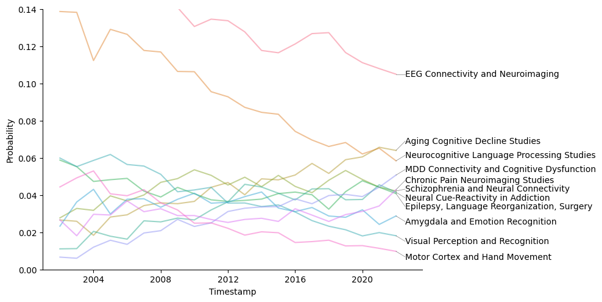

```python
# these are manually generated vertical offsets for the labels,
# which will differ between models
offsets = defaultdict(lambda: None)
offsets[(250, 25)] = defaultdict(lambda: 0)
offsets[(250, 25)][3] = -.003
offsets[(250, 25)][5] = .002
offsets[(250, 25)][1] = -.001
offsets[(250, 25)][2] = .001
offsets[(250, 25)][7] = -.001

offsets[(500, 40)] = defaultdict(lambda: 0)
offsets[(500, 40)][2] = .005
offsets[(500, 40)][3] = .001

offsets[(500, 40)][1] = .003
offsets[(500, 40)][8] = .003
offsets[(500, 40)][9] = .005

offsets[(500, 40)][11] = -.003
offsets[(500, 40)][6] = -.003
offsets[(500, 40)][7] = -.003
offsets[(500, 40)][4] = -.007
offsets[(500, 40)][5] = -.003

plot_top_topics(topics_over_time, topic_model,
                    minclust, nneighbors,
                    ntopics_to_plot=ntopics_to_plot,
                    offset=offsets[(min_cluster_size, n_neighbors)])
plt.ylim(0, 0.14)
```

We can see that there are some topics that rise substantially over the course of the last two decades, and others that fall. We can quantify this by computing the slope of each trend line and sorting by those values:

```python
slope_df = get_slopes(top_topics_over_time, topic_model)


pd.set_option('display.max_colwidth', None)
slope_df
```

|  | topic | slope | topicname |
| --- | --- | --- | --- |
| 1 | 1 | -0.004133 | Neurocognitive Language Processing Studies |
| 0 | 0 | -0.002699 | EEG Connectivity and Neuroimaging |
| 6 | 6 | -0.002363 | Visual Perception and Recognition |
| 10 | 11 | -0.002111 | Motor Cortex and Hand Movement |
| 4 | 4 | -0.000567 | Epilepsy, Language Reorganization, Surgery |
| 7 | 7 | -0.000325 | Amygdala and Emotion Recognition |
| 9 | 9 | 0.000303 | Chronic Pain Neuroimaging Studies |
| 3 | 3 | 0.000683 | Schizophrenia and Neural Connectivity |
| 5 | 5 | 0.001653 | Neural Cue-Reactivity in Addiction |
| 8 | 8 | 0.001986 | MDD Connectivity and Cognitive Dysfunction |
| 2 | 2 | 0.002144 | Aging Cognitive Decline Studies |

This shows that the majority of topics showing negative slopes were related to basic cognitive neuroscience (language, EEG connectivity, visual perception, motor cortex and emotion regulation) while the majority of topics showing positive slopes were related to clincal disorders.

Now let's look at the relationships between these topics. We can take the original embeddings of the text (which have 384 dimensions) and embed them in a two-dimensional space for visualization, using the UMAP technique (which is also used under the hood by BERTopic).

```python
mapper = umap.UMAP(n_neighbors=25,
                   n_components=2,
                   min_dist=0.1, metric='cosine').fit(embeddings)
```

First, let's plot the entire space with all topics:

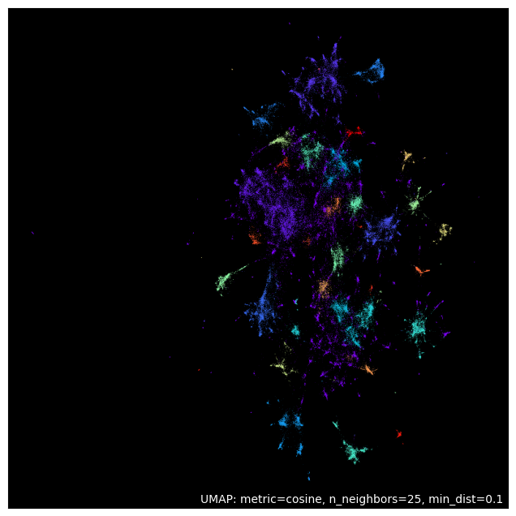

```python
topic_array = np.array(topic_model.topics_)
umap.plot.points(mapper, theme='fire', labels=topic_array, color_key_cmap='Paired',
                 background='black', show_legend=False)
```

This looks pretty cool but isn't very useful for actually understanding what's going on.

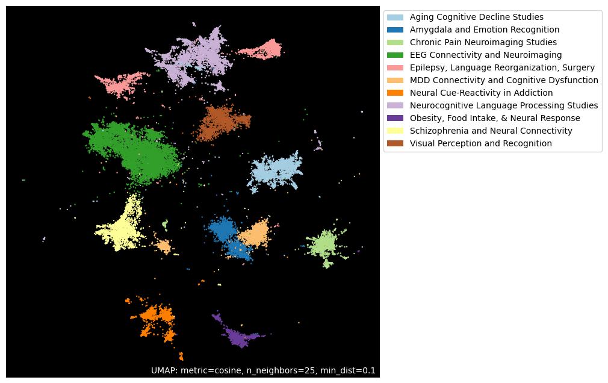

```python
topicnames = np.array([topic_model.get_topic(i)[0][0] for i in topic_array])
years_array = np.array(years)

subset_points = [True if topic_array[i] in slope_df.topic and years_array[i] > 2001 else False for i in range(len(topic_array))]
plt.figure(figsize=(12,10))
ax = umap.plot.points(mapper, labels=topicnames, color_key_cmap='Paired',
                 background='black', subset_points=subset_points)
legend = ax.get_legend()
legend.set_bbox_to_anchor((1, 1), transform=ax.transAxes)
```

Another thing we can look at is how the space changes over the years. To do this, let's plot the same data but color the data points by the year of publication:

[figure not shown]

```python
plt.figure(figsize=(8,10))

ax = umap.plot.points(mapper, labels=years_array, cmap='viridis', ax=plt.gca(),
                 background='black', subset_points=subset_points)
legend = ax.get_legend()
legend.set_bbox_to_anchor((1, 1), transform=ax.transAxes)
```

This shows that the more recent topics seem to be somewhat more central to the clusters, showing that papers within a topic become more similar over time.